# Homework 7 Responses

Zeyi Han, Shubhi Sharma, Margaret Swift

2020-04-01

## Exercise 1

*Conduct simulation experiments to determine how different values of `sig` and `tau` affect the behavior of `x`.*

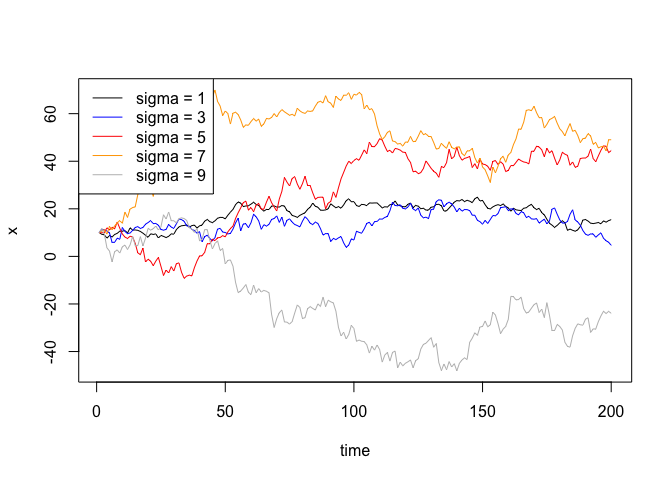

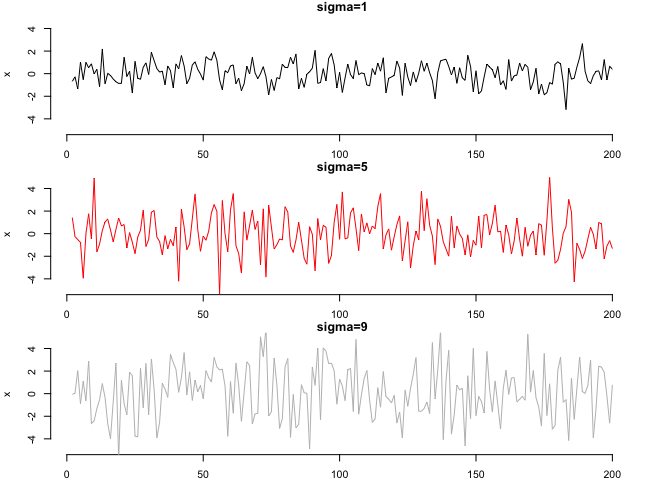

*Determine how these same parameters affect the standard deviation of `x` and `y`.*

Our results indicate that X with higher `sigma` fluctuates more. Since behaviour of `y` does not affect the behaviour of `x`, change of `tau` does not change the behaviour of `x.`

|  | sigma = 1 | sigma = 3 | sigma = 5 | sigma = 7 | sigma = 9 |
| --- | --- | --- | --- | --- | --- |
| x_std | 4.776166 | 4.455518 | 16.90982 | 13.93663 | 18.86847 |
| y_std_tau5 | 6.314538 | 6.581532 | 17.87544 | 14.59534 | 19.37818 |

| tau = 10 | tau = 15 | tau = 20 | tau = 25 | tau = 30 |
| --- | --- | --- | --- | --- |
| 17.19726 | 17.19921 | 16.71344 | 16.97799 | 17.43301 |

*Determine how the length of the series `nt` affects the standard deviation in `x` and in the differenced sequence of `x`.*

|  | t = 200 | t = 400 | t = 600 |
| --- | --- | --- | --- |
| Xx_std | 10.662275 | 10.641457 | 16.505009 |
| Xxdiff_std | 2.405413 | 2.994905 | 2.296756 |

## Exercise 2

Working in your group, analyze the following model in jags. Start by simulating the data set. Then write jags code to fit the model.

$$x_t \sim N(\alpha + \beta x_{t-1}, \sigma^2)$$

$$y_t \sim Poi( exp(x_t) )$$

We were trying to estimate two parameters here, $\beta$ and $\sigma^2$. The results of the jags model and trace plots of the parameters willl show the resulting distribution and value of $\beta$ and $\sigma^2$.

```
## Linked to JAGS 4.3.0
```

```
## Loaded modules: basemod,bugs
```

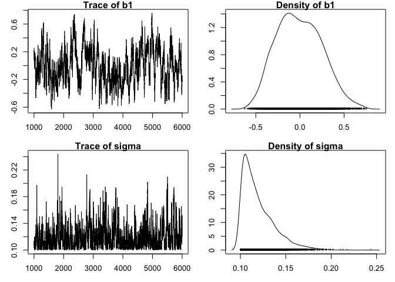

## Exercise 3

*Before running any more analysis, say what you think should be the variance on the process and the observations. Justify your answer.*

If the data have a wide spread, the prior variance on observations should be similarly large. However, the variance of the ydata is 0.98, which is pretty high. We would argue that a slightly lower variance would be acceptable. As for the variance on the process, we have no intuition on this, so would probably set it to be equal to whatever we feel is appropriate for the observation variance.

*How much ‘weight’ on the priors for $\sigma^2, \tau^2$ is needed to insure that the posterior distribution is close to your prior distribution? Explain how you manipulated prior weight to arrive at your answer.*

For the following chunk of code, I tried a weight (`wt`) of 1e3, 1e5, and 1e8.

```r
sigM <- .1
tauM <- .1
for (wt in c(1e3, 1e5, 1e8)) {
  sp <- varPrior(sigM, wt)
  tp <- varPrior(tauM, wt)
  ...
}
```

Unsurprisingly, as the weight on the priors increased, the posterior estimates for `sigma` and `tau` approached the prior values (0.1, 0.1):

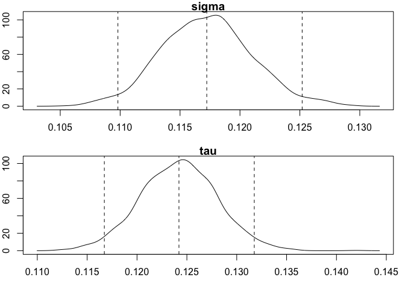

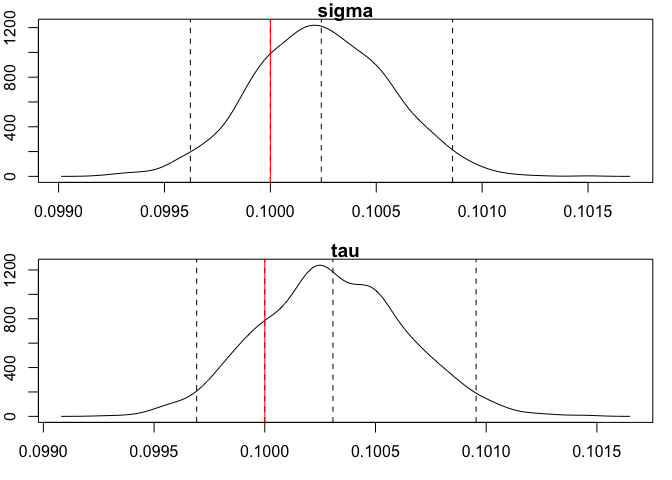

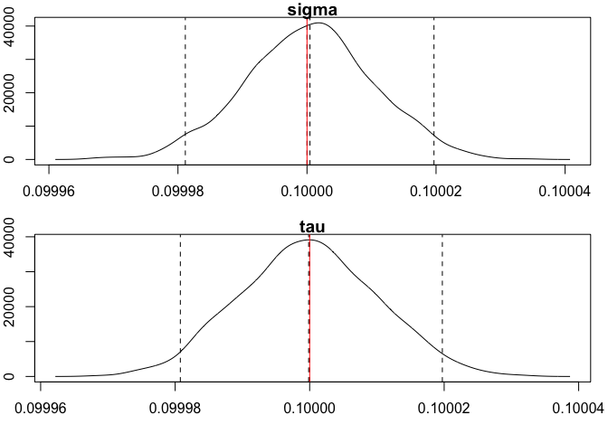

*How does the prior on $\sigma^2, \tau^2$ affect estimates of $\mathbf{\beta}$?*

```r
priors <- c(0.1, 0.4, 0.7)
for (i in 1:length(priors)) {
  sigM <- tauM <- priors[i]
  sp <- varPrior(sigM, nt)
  tp <- varPrior(tauM, nt/5)
  ...
}
```

In increasing the priors for $\sigma^2, \tau^2$ from 0.1 to 0.7, estimates for the $\mathbf{\beta}$’s don’t change too much, but their character is much more spread out. This makes sense, as I’m increasing the prior *variance*, and so as variance increases, densities will be more smeared out:

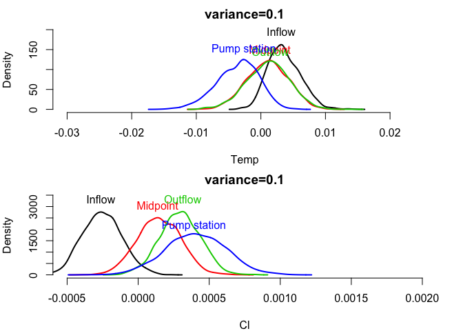

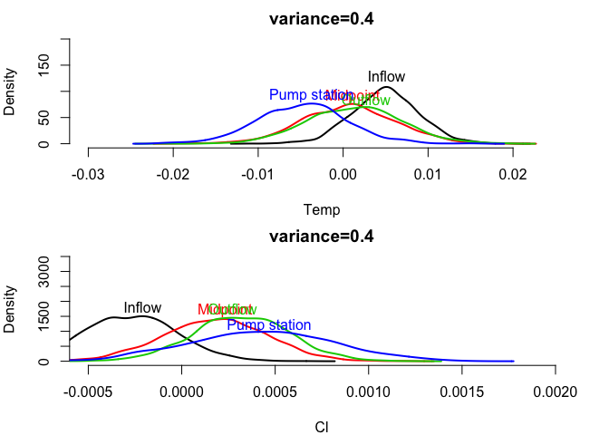

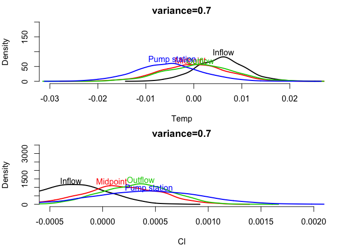

*Repeat the analysis with DON as the response variable and interpret results.*

With DON, the responses to temperature and Cl are similar in sign; however, all of the betas for Site and Site interactions with other variables have been flipped in sign. In addition, when TDN was the response variable, `sigma` and `tau` were overestimated; with DON, both are now underestimated (estimated values are less than the true value).

```
## $summary
##                         estimate        se      0.025     0.975 true value
## (Intercept)           -3.150e-02 0.0325700 -0.0959600 0.0341500          0
## prec                  -3.852e-04 0.0006418 -0.0016410 0.0009094          0
## Temp                   2.448e-03 0.0019040 -0.0012850 0.0062200          0
## SiteMidpoint           1.910e-02 0.0424000 -0.0610400 0.1061000          0
## SiteOutflow            2.702e-02 0.0438500 -0.0564000 0.1154000          0
## SitePump station      -8.509e-03 0.0431000 -0.0904900 0.0790400          0
## Cl                    -7.149e-05 0.0001033 -0.0002594 0.0001294          0
## Temp:SiteMidpoint     -1.804e-03 0.0024380 -0.0067060 0.0030310          0
## Temp:SiteOutflow      -1.824e-03 0.0026130 -0.0071120 0.0030740          0
## Temp:SitePump station -3.884e-04 0.0024130 -0.0053880 0.0043070          0
## SiteMidpoint:Cl        6.515e-05 0.0001160 -0.0001639 0.0002844          0
## SiteOutflow:Cl         5.731e-05 0.0001047 -0.0001496 0.0002464          0
## SitePump station:Cl    1.339e-04 0.0001609 -0.0001678 0.0004576          0
```

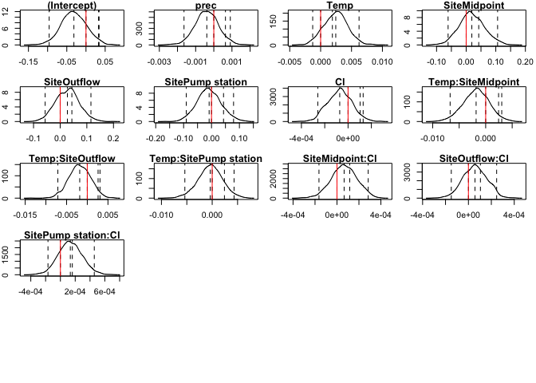

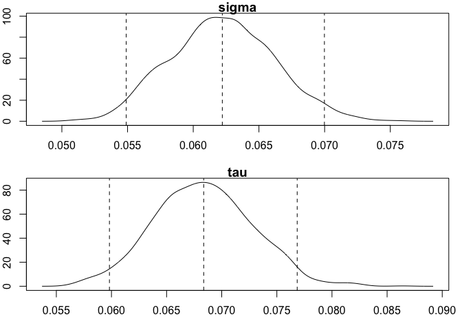

```
## $summary
##       estimate       se   0.025   0.975 true value
## sigma  0.06221 0.003925 0.05490 0.06998        0.1
## tau    0.06837 0.004483 0.05982 0.07684        0.1
```

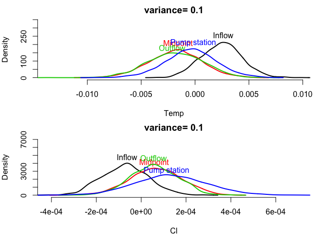

*What is the answer to the motivating question: Can total dissolved nitrogen (TDN) and dissolved organic nitrogen (DON) be explained by temperature, precipitation, and chlorine concentation ([Cl]), and does it differs between coastal streams?*

The effects of Chlorine and Temperature on TDN and DON are very much determined by the stream site. Although the sites `Midpoint` and `Outflow` are pretty similar to each other across the board, for both TDN and DON, `Inflow` and `Pump Station` have visibly different effects, when combined with chlorine and temperature, on our response variables.

## Appendix

```r
#----------------------------------------------------------------------------
# LOADING
knitr::opts_chunk$set(echo=FALSE, eval=TRUE, cache=FALSE)
pacman::p_load(ggplot2, dplyr, Rfast)
source('../clarkfunctions2020.R')
Rcpp::sourceCpp('../cppFns.cpp')

#-------------------------------------------------------------------------------
## EXERCISE 1
nt   <- 200                      #no. time intervals
time <- c(1:nt)                  #sample times
nm   <- 20                       #number of missing values
wm   <- sort(sample(c(2:nt),nm)) #which are missing
fullSig  <- c(1,3,5,7,9)                       #process err variance
tau  <- c(10, 15, 20, 25, 30)                       #obs error variance
x    <- matrix(rep(10,nt*5), nt,5)

for (i in 1:5){  # simulate x with different sigma
  for(t in 2:nt) {
    x[t,i] <- x[t-1,i] + rnorm(1,0,sqrt(fullSig[i]))
  }
}

# calculate y with different tau while sigma = 5
y <- matrix(rep(NA,nt*5), nt,5)
for( i in 1:5){   #simulate observations for x with sigma = 5
  y[,i]     <- rnorm(nt,x[,3],sqrt(tau[i]))
}
y[wm,] <- NA

# 1. How do different values of sig and tau affect the behavior of x?
# plot x with different sigma
plot(time, x[,1], type = "l", ylim= c(min(x), max(x)), ylab= "x")
color <- c("black", "blue", "red", "orange", "grey")
for(i in 2:5){ lines(time, x[,i], col = color[i]) }
legend("topleft", col = color, lty = c(1,1,1,1,1), legend = paste('sigma =', fullSig))

# Plot of variance straightened out.
inx <- c(1, 3, 5)
sig <- fullSig[inx]
color <- color[inx]
L <- length(sig)
par(mfrow=c(L,1), mar=c(2,4,1,3), bty='n')
for(i in 1:L){
  plot(time[-1], diff(x[,1]), type='l', col='white',
       ylim=c(-5,5), ylab= "x", main=paste0("sigma=", sig[i]))
  lines(time[-1], diff(x[,i]), col = color[i])
}
# 2. How do these same parameters affect the standard deviation of x and y?

# Culculate y from x with different sigma, while tau = 20
y2 <- matrix(rep(NA,nt*5), nt,5)
for( i in 1:5){   #simulate observations for x with sigma = 5
  y2[,i]     <- rnorm(nt,x[,i],sqrt(20))
}
y2[wm,] <- NA


x_std <- colVars(x,std=TRUE)
y_std_tau5 <- colVars(na.omit(y2),std=TRUE)
df <- as.matrix(rbind(x_std, y_std_tau5))
y_std_sig5 <- colVars(na.omit(y),std=TRUE)

knitr::kable(df,col.names = c("sigma = 1", "sigma = 3", "sigma = 5", "sigma = 7", "sigma = 9"))

knitr::kable(matrix(y_std_sig5,1,5),col.names = c("tau = 10", "tau = 15", "tau = 20", "tau = 25", "tau = 30"))
# 3. The effects of the length of time series (sig = 5)
simulate_x <- function(nt, sig){
  x    <- rep(10,nt)
  for(t in 2:nt) x[t] <- x[t-1] + rnorm(1,0,sqrt(sig))
  x
}
x200 <- simulate_x(200,5)
x400 <- simulate_x(400,5)
x600 <- simulate_x(600,5)
Xx <- cbind(x200, x400, x600)

Xx_std <- colVars(Xx,std=TRUE)
Xx %>% diff() %>% colVars(Xx,std=TRUE) -> Xxdiff_std
df2 <- rbind(Xx_std,Xxdiff_std )
knitr::kable(as.matrix(df2),col.names = c("t = 200", "t = 400", "t = 600"))
#-------------------------------------------------------------------------------
## EXERCISE 2

require(rjags)
require(coda)
nt   <- 300                       #no. time intervals
time <- c(1:nt)                   #sample times
sig  <- .01                         #process err variance
x    <- rep(0,nt)
beta  <- matrix(runif(1, -.01,.01))             #coefficient vector length 1

for(t in 2:nt){

  x[t]<- rnorm(1, x[t-1]*beta, sig)

}


y <- rpois(nt, exp(x))


#model in jags

cat( "model {

     mu[1] ~ dnorm(x[1], 10)
     xg[1] <- mu[1]

     for(t in 2:nt) {
     mu[t] <- xg[t-1]* b1
     xg[t] ~ dnorm(mu[t],procErr)
     y[t] ~ dpois(exp(xg[t]))
     }

     procErr ~ dunif(0,10)
     sigma <- 1/procErr
     b1 ~ dunif(-1,1)
     }  ", fill=T,file="stateSpaceModel.txt" )

ssData   <- list(y = y, x = x, nt = nt )
parNames <- c('b1', 'sigma')

ssFit <- jags.model(data=ssData, file="stateSpaceModel.txt")


update(ssFit)

ssFit <- coda.samples(ssFit, variable.names = parNames,
                      n.iter=5000)

par(mar=c(3,3,1,1))
plot( as.mcmc(ssFit) )


#-------------------------------------------------------------------------------
## EXERCISE 3

#-------------------------------------------------------------------------------
# First I read the data and set up a design matrix for the sites and several
# covariates:

# Data and formula matrix
data <- read.csv('../dataFiles/combinedLevelChem2007.csv',header=T)
formula <- as.formula( ~ prec + Temp*Site + Cl*Site)
tmp <- model.frame(formula, data, na.action=na.pass)
z   <- model.matrix(formula, tmp)

# Find site levels
slevs  <- attr(data$Site,'levels')
sl     <- match(data$Site,slevs)

# Counts
ngroup <- length(slevs)
ns     <- ngroup - 1
nt     <- nrow(data)
q      <- ncol(z)

# X and Y
xnames <- colnames(z)
ynames <- c('TDN','DON')
vnames <- c('sigma', 'tau')

#-------------------------------------------------------------------------------
# multiple time series

last  <- which( diff(sl) == 1 )  # first and last row for each site
first <- c(1,last + 1)
last  <- c(last,nt)

#-------------------------------------------------------------------------------
# missing covariates, missing states
y <- data[,ynames[1]]            # use TDN as response; change to DON later.
v <- getMissX(z, y, first, last)
prows <- v$prows                 # t rows by site
rrows <- v$rrows                 # t+1 rows by site
missz <- v$missx
missy <- v$missy                 # missing y index in stacked data
missY <- v$missY                 # missing y by site as a list

priorx   <- colMeans(z,na.rm=T)  # prior mean for missing covariates
z[missz] <- priorx[missz[,2]]    # initial missing z

sigM <- .1
tauM <- .1
for (wt in c(1e3, 1e5, 1e8)) {
  sp <- varPrior(sigM, wt)
  tp <- varPrior(tauM, wt)
  ...
}
sigM <- .1
tauM <- .1
ng     <- 2000
keep  <- 200:ng
for (wt in c(1e3, 1e5, 1e8)) {
  sp <- varPrior(sigM, wt)
  tp <- varPrior(tauM, wt)

  sg <- 1/rgamma(1,sp[1],sp[2])     #initialize variance values
  tg <- 1/rgamma(1,tp[1],tp[2])
  bg <- matrix(0,q,1)

  tmp <- initialStatesSS(y)         #initial missing y
  xg  <- tmp$x

  #-------------------------------------------------------------------------------
  # Gibbs Sampling
  vgibbs <- matrix(0, ng, 2)
  xgibbs <- matrix(0, ng, nt)
  bgibbs <- matrix(0, ng, q)
  zgibbs <- matrix(0, ng, length(missz))
  colnames(vgibbs) <- vnames
  colnames(bgibbs) <- xnames
```

```r
  for(g in 1:ng){
    bg <- .updateBeta(z[prows,], xg[rrows] - xg[prows], sigma=sg,
                      priorIVB=diag(.001,q), priorB=matrix(0,q)) #
    mu <- z%*%bg  # mean vector
    for(j in 1:ngroup){
      jj <- first[j]:last[j]
      xg[jj] <- updateSSRW(states=xg[jj], yy=y[jj], zb=mu[jj], missing=missY[[j]],
                           tg=tg, sg=sg)
    }
    sg <- updateVariance(xg[rrows],xg[prows] + mu[prows],sp[1],sp[2])
    tg <- updateVariance(y[-missy],xg[-missy],tp[1],tp[2])
    z[missz] <- imputeX( missx = missz, xx = z[prows,],
                         yy = xg[prows] - xg[rrows],
                         bg = bg, sg, priorx )[missz]
    vgibbs[g,] <- c(sg,tg)
    xgibbs[g,] <- xg
    bgibbs[g,] <- bg
    zgibbs[g,] <- z[missz]
  }
  .processPars(vgibbs[keep,],xtrue=c(sigM,tauM),DPLOT=T, burnin = 200)
}
priors <- c(0.1, 0.4, 0.7)
for (i in 1:length(priors)) {
  sigM <- tauM <- priors[i]
  sp <- varPrior(sigM, nt)
  tp <- varPrior(tauM, nt/5)
  ...
}
ng     <- 2000
keep  <- 200:ng
priors <- c(0.1, 0.4, 0.7)
xlims <- data.frame(temp=c(-0.03, 0.025), cl=c(-0.0005, 0.002))
ylims <- data.frame(temp=c(0, 200), cl=c(0, 3500))
for (i in 1:length(priors)) {
  sigM <- tauM <- priors[i]
  sp <- varPrior(sigM, nt)
  tp <- varPrior(tauM, nt/5)

  sg <- 1/rgamma(1,sp[1],sp[2])     #initialize variance values
  tg <- 1/rgamma(1,tp[1],tp[2])
  bg <- matrix(0,q,1)

  tmp <- initialStatesSS(y)         #initial missing y
  xg  <- tmp$x

  #-------------------------------------------------------------------------------
  # Gibbs Sampling
  vgibbs <- matrix(0, ng, 2)
  xgibbs <- matrix(0, ng, nt)
  bgibbs <- matrix(0, ng, q)
  zgibbs <- matrix(0, ng, length(missz))
  colnames(vgibbs) <- vnames
  colnames(bgibbs) <- xnames

  for(g in 1:ng){
    bg <- .updateBeta(z[prows,], xg[rrows] - xg[prows], sigma=sg,
                      priorIVB=diag(.001,q), priorB=matrix(0,q)) #
    mu <- z%*%bg  # mean vector
    for(j in 1:ngroup){
      jj <- first[j]:last[j]
      xg[jj] <- updateSSRW(states=xg[jj], yy=y[jj], zb=mu[jj], missing=missY[[j]],
                           tg=tg, sg=sg)
    }
    sg <- updateVariance(xg[rrows],xg[prows] + mu[prows],sp[1],sp[2])
    tg <- updateVariance(y[-missy],xg[-missy],tp[1],tp[2])
    z[missz] <- imputeX( missx = missz, xx = z[prows,],
                         yy = xg[prows] - xg[rrows],
                         bg = bg, sg, priorx )[missz]
    vgibbs[g,] <- c(sg,tg)
    xgibbs[g,] <- xg
    bgibbs[g,] <- bg
    zgibbs[g,] <- z[missz]
  }
  # .processPars(bgibbs[keep,],xtrue=bg*0,DPLOT=T, burnin = 200)
  vars <- c('Temp', 'Cl')
  par(mfrow=c(2,1), bty='n', mar=c(4,4,2,2))
  sites <- levels(data$Site)
  for(k in 1:2){

    wk <- grep(vars[k],colnames(bgibbs))
    bk <- bgibbs[keep,wk]

    xlim <- xlims[,k]#range(bk)
    ylim <- ylims[,k]#8/diff(xlim)
    plot(NULL, xlim=xlim,ylim=ylim,xlab=vars[k],ylab='Density', main=paste0('variance=', sigM))

    for(j in 1:ncol(bk)){
      dk <- density(bk[,j])
      lines(dk[[1]],dk[[2]],col=j, lwd=2)
      wmax <- which.max(dk[[2]])
      text( dk[[1]][wmax], 1.2*dk[[2]][wmax], sites[j] ,col=j)
    }
  }
}
#-------------------------------------------------------------------------------
# missing covariates, missing states
y <- data[,ynames[2]]        # use TDN as response; change to DON later.
v <- getMissX(z, y, first, last)
prows <- v$prows                 # t rows by site
rrows <- v$rrows                 # t+1 rows by site
missz <- v$missx
missy <- v$missy                 # missing y index in stacked data
missY <- v$missY                 # missing y by site as a list

priorx   <- colMeans(z,na.rm=T)  # prior mean for missing covariates
z[missz] <- priorx[missz[,2]]    # initial missing z

#-------------------------------------------------------------------------------
# Initial values for missing states come from a function initialStatesSS.

sigM <- .1                        #prior mean variances
tauM <- .1
wt <- 100
sp <- varPrior(sigM, wt)          #varPrior is gonna spit out a,b for gamma
tp <- varPrior(tauM, wt/5)        #weak prior

sg <- 1/rgamma(1,sp[1],sp[2])     #initialize variance values
tg <- 1/rgamma(1,tp[1],tp[2])
bg <- matrix(0,q,1)

tmp <- initialStatesSS(y)         #initial missing y
xg  <- tmp$x

#-------------------------------------------------------------------------------
# Gibbs Sampling
ng     <- 2000
vgibbs <- matrix(0, ng, 2)
xgibbs <- matrix(0, ng, nt)
bgibbs <- matrix(0, ng, q)
zgibbs <- matrix(0, ng, length(missz))
colnames(vgibbs) <- vnames
colnames(bgibbs) <- xnames

for(g in 1:ng){

  # parameters
  bg <- .updateBeta(z[prows,], xg[rrows] - xg[prows], sigma=sg,
                    priorIVB=diag(.001,q), priorB=matrix(0,q)) #
  mu <- z%*%bg  # mean vector

  # latent variables by site
  for(j in 1:ngroup){
    jj <- first[j]:last[j]
    xg[jj] <- updateSSRW(states=xg[jj], yy=y[jj], zb=mu[jj], missing=missY[[j]],
                         tg=tg, sg=sg)
  }

  # variances
  sg <- updateVariance(xg[rrows],xg[prows] + mu[prows],sp[1],sp[2])
  tg <- updateVariance(y[-missy],xg[-missy],tp[1],tp[2])

  # missing observations
  z[missz] <- imputeX( missx = missz, xx = z[prows,],
                       yy = xg[prows] - xg[rrows],
                       bg = bg, sg, priorx )[missz]
  vgibbs[g,] <- c(sg,tg)
  xgibbs[g,] <- xg
  bgibbs[g,] <- bg
  zgibbs[g,] <- z[missz]
}

#-------------------------------------------------------------------------------
# Latent states plots

keep  <- 200:ng
xpost <- t( apply(xgibbs[keep,],2,quantile,c(.5,.025,.975)) )
ylim  <- range(xpost)

.processPars(bgibbs[keep,],xtrue=bg*0,DPLOT=T, burnin = 200)
.processPars(vgibbs[keep,],xtrue=c(sigM,tauM),DPLOT=T, burnin = 200)

vars <- c('Temp', 'Cl')
par(mfrow=c(2,1), bty='n', mar=c(4,4,2,2))
sites <- levels(data$Site)
for(k in 1:2){

  wk <- grep(vars[k],colnames(bgibbs))
  bk <- bgibbs[keep,wk]

  xlim <- range(bk)
  ymax <- 8/diff(xlim)
  plot(NULL, xlim=xlim,ylim=c(0,ymax),xlab=vars[k],ylab='Density', main=paste('variance=', sigM))
```

```r
  for(j in 1:ncol(bk)){
    dk <- density(bk[,j])
    lines(dk[[1]],dk[[2]],col=j, lwd=2)
    wmax <- which.max(dk[[2]])
    text( dk[[1]][wmax], 1.2*dk[[2]][wmax], sites[j] ,col=j)
  }
}
```